# 8_TS_BDBA_2022F_Midterm

## 3.2 Create an ACF plot of the entire time series, depicting up to 36 lags: (0.67 points)

```
Response variable not specified, automatically selected `var = value`
```

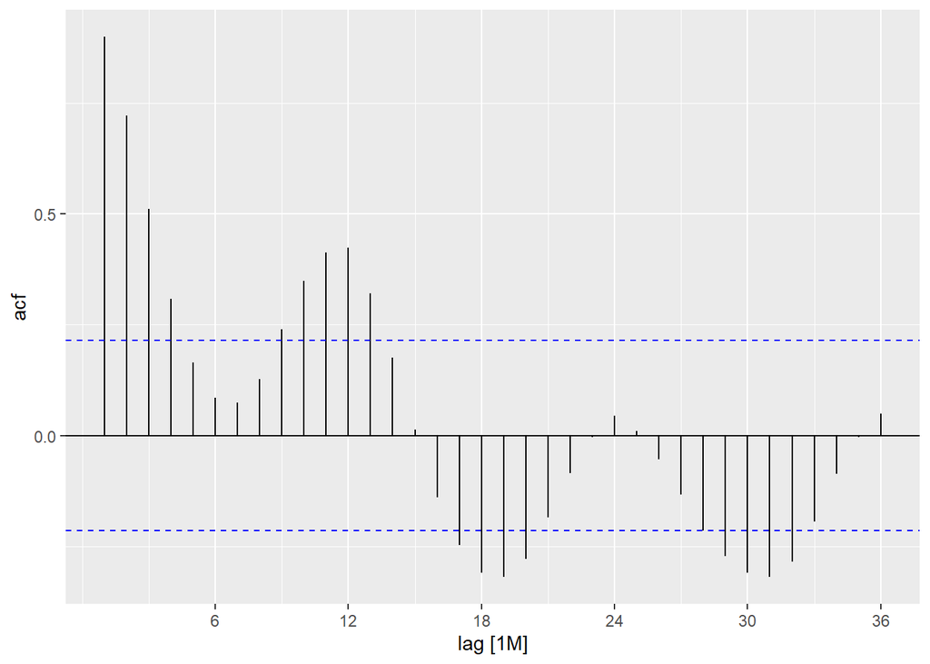

```r
sp_arrivals %>% ACF(lag_max = 36) %>% autoplot()
```

### 3.2.1 Which lag exhibits the strongest positive correlation? Why? (30-40 words max)

```r
# Lag 1 because for short lags and this dataset the effect of the trend dominates
# seems to dominate over the effect the seasonal + remainder components.
```

## 3.3 Create an ACF plot of the remainder component of the X11 decomposition. Depict 36 lags. (0.67 points)

```
Response variable not specified, automatically selected `var = irregular`
```

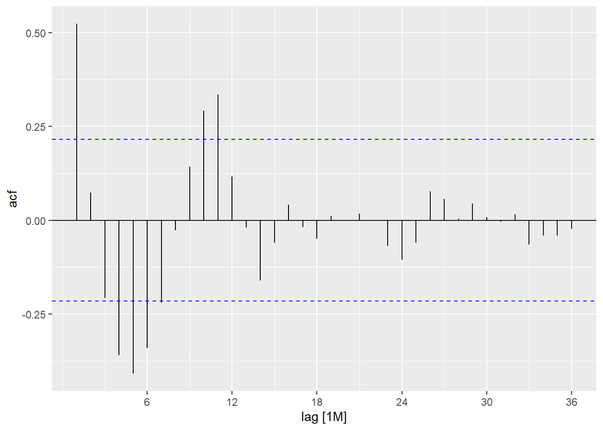

```r
x11_dcmp %>% select(irregular) %>% ACF(lag_max = 36) %>% autoplot()
```

### 3.3.1 Does the remainder component look like white noise? (30 words).

```r
# No, clearly there is a lot of autocorrelation left in the remainder components.
# The decomposition is improvable.
```

# 4. Cross-validation (2 points)

## 4.1 Create a sub-time series that contains only observations prior to 2020. Call this time series `sp_arrivals_2019` (0.25 points).

```r
sp_arrivals_2019 <- sp_arrivals %>% filter(year(ym) <= 2019)

sp_arrivals_2019
```

```
# A tsibble: 51 x 2 [1M]
         ym   value
      <mth>   <dbl>
 1 2015 Oct 6432341
 2 2015 Nov 3754802
 3 2015 Dec 3512914
 4 2016 Jan 3526537
 5 2016 Feb 3678726
 6 2016 Mar 4627206
 7 2016 Apr 6086327
 8 2016 May 7111154
 9 2016 Jun 7552758
10 2016 Jul 9545792
# … with 41 more rows
```

## 4.2 Using `sp_arrivals_2019`, create a series of training datasets for cross-validation fulfilling the following (0.25 points).

- The smallest dataset contains all the observations up to and including Oct 2017.
- The datasets increase one observation at a time

```r
init_size <- sp_arrivals_2019 %>% filter(ym <= yearmonth("2017 Oct")) %>% nrow()

sp_arrivals_2019_cv <- sp_arrivals_2019 %>%
                  stretch_tsibble(.init = init_size, .step = 1)

sp_arrivals_2019_cv
```

```
# A tsibble: 1,026 x 3 [1M]
# Key:       .id [27]
         ym   value   .id
      <mth>   <dbl> <int>
 1 2015 Oct 6432341     1
 2 2015 Nov 3754802     1
 3 2015 Dec 3512914     1
 4 2016 Jan 3526537     1
 5 2016 Feb 3678726     1
 6 2016 Mar 4627206     1
 7 2016 Apr 6086327     1
 8 2016 May 7111154     1
 9 2016 Jun 7552758     1
10 2016 Jul 9545792     1
# … with 1,016 more rows
```

## 4.3 Fit the following models to each of the training datasets (0.5 points)

- Mean model
- Naive model
- Drift model
- Seasonal naive model
- Decomposition model using:
  - The STL decomposition with-non default values defined in 2.4. Alternatively you may use the standard STL arguments.
  - The drift component for the seasonally adjusted component
  - The SMAIVE component for the seasonal component

```r
fit_cv <- sp_arrivals_2019_cv %>% model(
    mean=MEAN(value),
    naive=NAIVE(value),
    snaive=SNAIVE(value),
    drift=RW(value ~ drift()),
    dcmp=decomposition_model(
              STL(value ~ trend(window = 5) + season(window = 5)),
              RW(season_adjust ~ drift())
          )

)

fit_cv
```

```
# A mable: 27 x 6
# Key:     .id [27]
     .id    mean   naive   snaive         drift                      dcmp
   <int> <model> <model>  <model>       <model>                   <model>
 1     1  <MEAN> <NAIVE> <SNAIVE> <RW w/ drift> <STL decomposition model>
 2     2  <MEAN> <NAIVE> <SNAIVE> <RW w/ drift> <STL decomposition model>
 3     3  <MEAN> <NAIVE> <SNAIVE> <RW w/ drift> <STL decomposition model>
 4     4  <MEAN> <NAIVE> <SNAIVE> <RW w/ drift> <STL decomposition model>
 5     5  <MEAN> <NAIVE> <SNAIVE> <RW w/ drift> <STL decomposition model>
 6     6  <MEAN> <NAIVE> <SNAIVE> <RW w/ drift> <STL decomposition model>
 7     7  <MEAN> <NAIVE> <SNAIVE> <RW w/ drift> <STL decomposition model>
 8     8  <MEAN> <NAIVE> <SNAIVE> <RW w/ drift> <STL decomposition model>
 9     9  <MEAN> <NAIVE> <SNAIVE> <RW w/ drift> <STL decomposition model>
10    10  <MEAN> <NAIVE> <SNAIVE> <RW w/ drift> <STL decomposition model>
# … with 17 more rows
```

## 4.4 Perform forecasts of up to one seasonal period. Then compute the error metrics **for each of the forecast horizons and models** using `accuracy()`. Order the models by increasing RMSE for each forecast horizon. (0.75 points)

```r
fc_cv <- fit_cv %>%
          forecast(h=12) %>%
          group_by(.id, .model) %>%
          mutate(
            h = row_number()
          ) %>%
          ungroup() %>%
          as_fable(response = "value", distribution = value)

summary_cv_h <-
  fc_cv %>%
  accuracy(sp_arrivals_2019, by=c("h", ".model")) %>%
  arrange(h, RMSE)
```

### 4.4.1 Filter the table above so that only the best 3 models for each forecast horizon are shown

```r
summary_cv_h %>%
  group_by(h) %>%
  mutate(row = row_number()) %>%
  filter(row <= 3) %>%
  select(-row)
```

```
# A tibble: 36 × 11
# Groups:   h [12]
       h .model .type       ME     RMSE    MAE    MPE  MAPE  MASE RMSSE     ACF1
   <int> <chr>  <chr>    <dbl>    <dbl>  <dbl>  <dbl> <dbl> <dbl> <dbl>    <dbl>
 1     1 snaive Test    74116.  236292. 1.95e5  1.74   3.17 0.592 0.549 -0.0167
 2     1 dcmp   Test    22646.  273955. 2.17e5  0.389  3.23 0.659 0.637 -0.386
 3     1 naive  Test  -114046. 1347394. 1.05e6 -4.57  17.4  3.17  3.13   0.500
 4     2 snaive Test    65309.  233672. 1.91e5  1.54   3.03 0.580 0.543 -0.00320
 5     2 dcmp   Test    20691.  282538. 2.28e5  0.477  3.10 0.691 0.657  0.0245
 6     2 naive  Test  -108110. 2304939. 1.99e6 -8.99  33.1  6.04  5.36   0.728
 7     3 snaive Test    68360.  238485. 1.99e5  1.61   3.15 0.603 0.554  0.00458
 8     3 dcmp   Test     3432.  272993. 2.23e5  0.482  3.33 0.675 0.635  0.135
 9     3 mean   Test   506787. 2335242. 2.14e6 -3.84  33.1  6.47  5.43   0.766
10     4 snaive Test    62598.  239987. 1.99e5  1.47   3.07 0.603 0.558  0.00113
# … with 26 more rows
```

## 4.5 Compute the average RMSE of each model for all the forecast horizons (0.75 points).

```r
summary_cv <-
  fc_cv %>%
  accuracy(sp_arrivals_2019, by=c(".model")) %>%
  arrange(RMSE)
summary_cv
```

```
# A tibble: 5 × 10
  .model .type      ME     RMSE      MAE   MPE  MAPE  MASE RMSSE   ACF1
  <chr>  <chr>   <dbl>    <dbl>    <dbl> <dbl> <dbl> <dbl> <dbl>  <dbl>
1 snaive Test   67975.  229929.  191130.  1.54  2.98 0.579 0.534 0.0498
2 dcmp   Test  -97638.  318320.  256681. -1.12  3.70 0.778 0.740 0.448
3 mean   Test  606761. 2275396. 2081977. -1.81 31.5  6.31  5.29  0.781
4 naive  Test  410494. 3119063. 2526764. -5.07 39.1  7.66  7.25  0.908
5 drift  Test  418076. 3405551. 2802734. -4.87 43.6  8.49  7.92  0.927
```

# 5. Single train-test split (2.5 points)

## 5.1 Fit a seasonal naive model to `sp_arrivals_2019`. Perform forecasts of up to one year ahead. (0.5 points)

```r
fit <-
  sp_arrivals_2019 %>%
  model(
    snaive = SNAIVE(value)
  )

fc <- fit %>% forecast(h=12)

fc
```

```
# A fable: 12 x 4 [1M]
# Key:     .model [1]
   .model       ym               value    .mean
   <chr>     <mth>              <dist>    <dbl>
 1 snaive 2020 Jan N(4195641, 1.9e+11)  4195641
 2 snaive 2020 Feb N(4380504, 1.9e+11)  4380504
 3 snaive 2020 Mar N(5649577, 1.9e+11)  5649577
 4 snaive 2020 Apr N(7146033, 1.9e+11)  7146033
 5 snaive 2020 May N(7919204, 1.9e+11)  7919204
 6 snaive 2020 Jun N(8833893, 1.9e+11)  8833893
 7 snaive 2020 Jul N(9873270, 1.9e+11)  9873270
 8 snaive 2020 Aug   N(1e+07, 1.9e+11) 10118366
 9 snaive 2020 Sep N(8845152, 1.9e+11)  8845152
10 snaive 2020 Oct N(7587749, 1.9e+11)  7587749
11 snaive 2020 Nov N(4655021, 1.9e+11)  4655021
12 snaive 2020 Dec N(4304741, 1.9e+11)  4304741
```

## 5.2 Compute the average RMSE of the previous forecasts (averaged over all forecast horizons) (0.5 points)

```r
summary <- fc %>% accuracy(sp_arrivals)

summary
```

```
# A tibble: 1 × 10
  .model .type        ME     RMSE     MAE   MPE  MAPE  MASE RMSSE  ACF1
  <chr>  <chr>     <dbl>    <dbl>   <dbl> <dbl> <dbl> <dbl> <dbl> <dbl>
1 snaive Test  -5381337. 6116405. 5389144  -Inf   Inf  16.3  14.2 0.669
```

## 5.3 Cumpute the difference between the average RMSE of the SNAIVE model on these forecasts with the average (over all horizons) RMSE of the SNAIVE of the cross-validated metrics of point 4.5. (0.75 points)

```r
(summary %>% pull(RMSE)) - (summary_cv %>% filter(.model=="snaive") %>% pull(RMSE))
```

```
[1] 5886476
```

### 5.3.1 What are the units of this result? (20 words max)

```r
# The units are tourists, the same units of the original time series.
```

### 5.3.2 How would you interpret this result? (75 words max)

```r
# The RMSE of the SNAIVE model beyond 2019 is much greater than before because
# of the COVID crisis, which completely changed the dynamics of the time series.

# Cross validation does not protect against abrupt external changes.
```

## 5.4 Depict the forecasts provided by the SNAIVE model together with the actual values of the time series beyond 2020 (0.75 points)

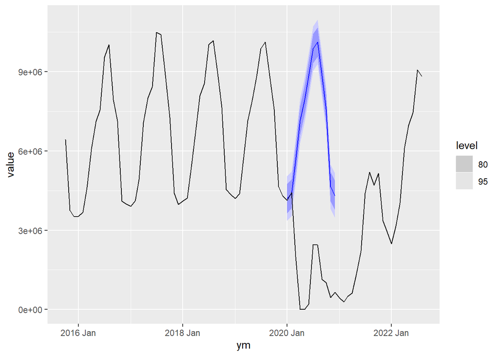

```r
fc %>%
  autoplot(sp_arrivals)
```